# Maria Zakaryan, 2129276

# **Bioinformatics I exam project of RNA-seq analysis.**

## Step 1: Data from Expression Atlas

The experiment chosen from Expression Atlas is:

#### Next Generation Sequencing identifying the dosage compensation state in human endometrial carcinoma and adjacent tissues. [GEO: GSE56087](https://www.ncbi.nlm.nih.gov/geo/query/acc.cgi?acc=GSE56087)

This differential experiment was done using RNA-seq technology by having 9 individuals with 36 samples, where 18 samples were the normal non-cancerous adjacent ones and the other 18 were the endometrial cancerous. Each individual had 2 samples takes from both tissues. The tissues were generated by Illumina 100-nucleotide paired-end sequencing. The main aim of the research was to understand if dosage compensation is completed properly in cancerous cell, or if some genes get over-activated in cancer tissue.

## Step 2: DESeq2

#### **0)Activating all the necessary libraries for this step**

```r
library(DESeq2)
```

```r
library(ggplot2)
library(pheatmap)
library(RColorBrewer)
library(EnhancedVolcano)
```

#### 1)Setting the working directory

```r
setwd("~/Bioinformatics I/Exam project")
```

#### 2)Loading the experiment design data

```r
colData <- read.delim("E-GEOD-56087-experiment-design.tsv", header = TRUE, stringsAsFactors = FALSE)
rownames(colData) <- colData[, 1]  #Run IDs as rownames
colData <- colData[, -1]           #Drop the first column
colnames(colData)[3] <- "condition"
```

```r
head(colData)
```

```
##            Sample.Characteristic.clinical.information.
## SRR1200850                      adjacent normal tissue
## SRR1200851                      adjacent normal tissue
## SRR1200852                           endometrial tumor
## SRR1200853                           endometrial tumor
## SRR1200854                      adjacent normal tissue
## SRR1200855                      adjacent normal tissue
##            Sample.Characteristic.Ontology.Term.clinical.information.
## SRR1200850                                                        NA
## SRR1200851                                                        NA
## SRR1200852                                                        NA
## SRR1200853                                                        NA
## SRR1200854                                                        NA
## SRR1200855                                                        NA
##                        condition Sample.Characteristic.Ontology.Term.disease.
## SRR1200850                normal  http://purl.obolibrary.org/obo/PATO_0000461
## SRR1200851                normal  http://purl.obolibrary.org/obo/PATO_0000461
## SRR1200852 endometrial carcinoma         http://www.ebi.ac.uk/efo/EFO_1001512
## SRR1200853 endometrial carcinoma         http://www.ebi.ac.uk/efo/EFO_1001512
## SRR1200854                normal  http://purl.obolibrary.org/obo/PATO_0000461
## SRR1200855                normal  http://purl.obolibrary.org/obo/PATO_0000461
##            Sample.Characteristic.individual.
## SRR1200850                        donor No.1
## SRR1200851                        donor No.1
## SRR1200852                        donor No.1
## SRR1200853                        donor No.1
## SRR1200854                        donor No.2
## SRR1200855                        donor No.2
##            Sample.Characteristic.Ontology.Term.individual.
## SRR1200850                                              NA
## SRR1200851                                              NA
## SRR1200852                                              NA
## SRR1200853                                              NA
## SRR1200854                                              NA
## SRR1200855                                              NA
##            Sample.Characteristic.organism.
## SRR1200850                    Homo sapiens
## SRR1200851                    Homo sapiens
## SRR1200852                    Homo sapiens
## SRR1200853                    Homo sapiens
```

[output cut: 29 more lines]

```
## SRR1200855                     female
##               Sample.Characteristic.Ontology.Term.sex. Factor.Value.disease.
## SRR1200850 http://purl.obolibrary.org/obo/PATO_0000383                normal
## SRR1200851 http://purl.obolibrary.org/obo/PATO_0000383                normal
## SRR1200852 http://purl.obolibrary.org/obo/PATO_0000383 endometrial carcinoma
## SRR1200853 http://purl.obolibrary.org/obo/PATO_0000383 endometrial carcinoma
## SRR1200854 http://purl.obolibrary.org/obo/PATO_0000383                normal
## SRR1200855 http://purl.obolibrary.org/obo/PATO_0000383                normal
##                    Factor.Value.Ontology.Term.disease. Analysed
## SRR1200850 http://purl.obolibrary.org/obo/PATO_0000461      Yes
## SRR1200851 http://purl.obolibrary.org/obo/PATO_0000461      Yes
## SRR1200852        http://www.ebi.ac.uk/efo/EFO_1001512      Yes
## SRR1200853        http://www.ebi.ac.uk/efo/EFO_1001512      Yes
## SRR1200854 http://purl.obolibrary.org/obo/PATO_0000461      Yes
## SRR1200855 http://purl.obolibrary.org/obo/PATO_0000461      Yes
```

#### 3)Loading the raw counts data

```r
counts <- read.delim("E-GEOD-56087-raw-counts.tsv", header = TRUE, stringsAsFactors = FALSE)

counts <- counts[, -2] #remove gene sybmol column

rownames(counts) <- counts[, 1] #setting gene IDs as rownames
counts <- counts[, -1]
```

```r
head(counts)
```

```
##                 SRR1200865 SRR1200851 SRR1200866 SRR1200875 SRR1200873
## ENSG00000000003        163        237        143        214        330
## ENSG00000000005          2          4          4          1          1
## ENSG00000000419        107        167        271        263        183
## ENSG00000000457         43         55         42         72         91
## ENSG00000000460         11         11         15          9         12
## ENSG00000000938          7         19          2         33         29
##                 SRR1200862 SRR1200872 SRR1200870 SRR1200854 SRR1200884
## ENSG00000000003        210        362        250        187        541
## ENSG00000000005          1          0          1          3          0
## ENSG00000000419        156        173        209        131        417
## ENSG00000000457         51         78         93         21         67
## ENSG00000000460         18          9         14          6         34
## ENSG00000000938         16         22         17          8         25
##                 SRR1200853 SRR1200857 SRR1200852 SRR1200867 SRR1200860
## ENSG00000000003        219         71        208        108        264
## ENSG00000000005          1          1          1          3          1
## ENSG00000000419        170         78        183        280        154
## ENSG00000000457         72         13         70         29         72
## ENSG00000000460         24          2         20         14          7
## ENSG00000000938          6          5         12          6         22
##                 SRR1200877 SRR1200879 SRR1200881 SRR1200876 SRR1200856
## ENSG00000000003        311        333        651        279         76
## ENSG00000000005          2          1         12          1          0
## ENSG00000000419        321        412        368        309         69
## ENSG00000000457        107         94        121         99         12
## ENSG00000000460         20         21         28         19          1
## ENSG00000000938         35         13         21         18          3
##                 SRR1200861 SRR1200880 SRR1200858 SRR1200874 SRR1200864
## ENSG00000000003        252        673        243        179        175
## ENSG00000000005          2         16          0          0          0
## ENSG00000000419        157        357        145        243        118
## ENSG00000000457         39         82         51         56         33
## ENSG00000000460         10         40         13         15         17
## ENSG00000000938         39         14         10         35          7
##                 SRR1200859 SRR1200863 SRR1200868 SRR1200878 SRR1200882
## ENSG00000000003        263        216        205        315        406
## ENSG00000000005          3          0         14          2          0
## ENSG00000000419        148        190        477        354        401
## ENSG00000000457         46         57         70         90         81
## ENSG00000000460          9         21         26         19         14
## ENSG00000000938          7          8         14         19         20
##                 SRR1200869 SRR1200871 SRR1200855 SRR1200850 SRR1200883
## ENSG00000000003        193        294        183        210        435
## ENSG00000000005         17          3          1          3          6
## ENSG00000000419        513        237        120        163        424
## ENSG00000000457         77         86         32         55         83
## ENSG00000000460         32         11          6         12         21
## ENSG00000000938          9         15          8         14         21
##                 SRR1200885
## ENSG00000000003        541
## ENSG00000000005          3
## ENSG00000000419        391
## ENSG00000000457         82
## ENSG00000000460         31
## ENSG00000000938         33
```

#### 4)Making the DESeq dataset

```r
counts <- counts[, rownames(colData)]  #matching columns to colData

dds <- DESeqDataSetFromMatrix(countData = counts,
                              colData = colData,
                              design = ~ condition)
```

```
##   Note: levels of factors in the design contain characters other than
##   letters, numbers, '_' and '.'. It is recommended (but not required) to use
##   only letters, numbers, and delimiters '_' or '.', as these are safe characters
##   for column names in R. [This is a message, not a warning or an error]
```

#### 5)Filtering low expressed genes

```r
dds <- dds[rowSums(counts(dds)) > 1, ]
```

#### 6)DESeq pipeline

```r
dds <-DESeq(dds)
```

[output not shown]

[output not shown]

[output not shown]

```
## -- replacing outliers and refitting for 371 genes
## -- DESeq argument 'minReplicatesForReplace' = 7
## -- original counts are preserved in counts(dds)
```

[output not shown]

#### 7)PCA plot using vst() function

```
## using ntop=500 top features by variance
```

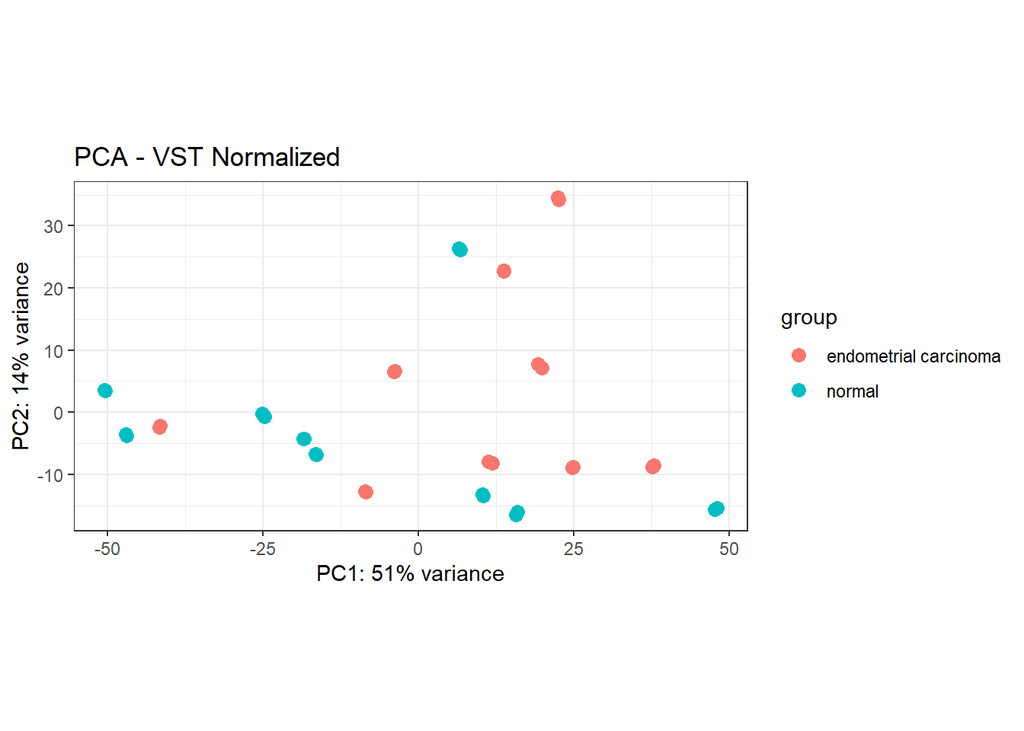

```r
vsd <- vst(dds, blind = FALSE)
DESeq2::plotPCA(vsd, ntop=500, intgroup = 'condition') + theme_bw() + ggtitle("PCA - VST Normalized")
```

#### 8)Heatmap of the sample-to-sample distances

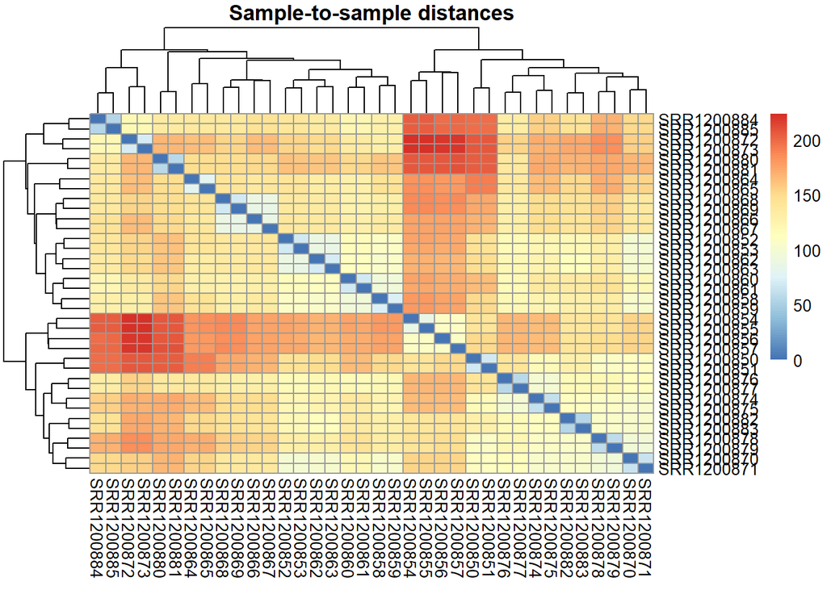

```r
sampleDists <- dist(t(assay(vsd)))
sampleDistMatrix <- as.matrix(sampleDists)

pheatmap(sampleDistMatrix,
         clustering_distance_rows = sampleDists,
         clustering_distance_cols = sampleDists,
         main = "Sample-to-sample distances")
```

#### 9)DE results

```r
res <- results(dds, contrast = c("condition", "endometrial carcinoma", "normal"))

#shrinks the noisy LFC results towards zero to make more stable and trustworthy results for making the plots more accurate.
res_shrinked <- lfcShrink(dds,
                 contrast = c("condition","endometrial carcinoma","normal"),
                 res = res,
                 type = "ashr")
```

```
## using 'ashr' for LFC shrinkage. If used in published research, please cite:
##     Stephens, M. (2016) False discovery rates: a new deal. Biostatistics, 18:2.
##     https://doi.org/10.1093/biostatistics/kxw041
```

```r
res
```

```
## log2 fold change (MLE): condition endometrial carcinoma vs normal
## Wald test p-value: condition endometrial carcinoma vs normal
## DataFrame with 39467 rows and 6 columns
##                  baseMean log2FoldChange     lfcSE        stat    pvalue
##                 <numeric>      <numeric> <numeric>   <numeric> <numeric>
## ENSG00000000003 252.43628     -0.0493088  0.148792   -0.331393  0.740348
## ENSG00000000005   2.80875      0.8632916  0.593676    1.454146  0.145906
## ENSG00000000419 227.62073     -0.1002025  0.169863   -0.589904  0.555255
## ENSG00000000457  58.21861     -0.0286660  0.112285   -0.255296  0.798494
## ENSG00000000460  14.81352      0.2464869  0.204634    1.204524  0.228387
## ...                   ...            ...       ...         ...       ...
## ENSG00000285981 0.0500293      0.1797997  2.964424  0.06065249  0.951636
## ENSG00000285984 0.1605162      0.5050425  2.122140  0.23798735  0.811891
## ENSG00000285991 0.8162421     -0.4382791  0.678156 -0.64628098  0.518097
## ENSG00000285993 0.1326327      0.0194991  2.638785  0.00738943  0.994104
## ENSG00000285994 2.0430149      0.3190142  0.542982  0.58752251  0.556853
##                      padj
##                 <numeric>
## ENSG00000000003  0.874587
## ENSG00000000005  0.380451
## ENSG00000000419  0.761376
## ENSG00000000457  0.904877
## ENSG00000000460  0.479726
## ...                   ...
## ENSG00000285981        NA
## ENSG00000285984        NA
## ENSG00000285991        NA
## ENSG00000285993        NA
## ENSG00000285994  0.762202
```

#### 10)Volcano plot

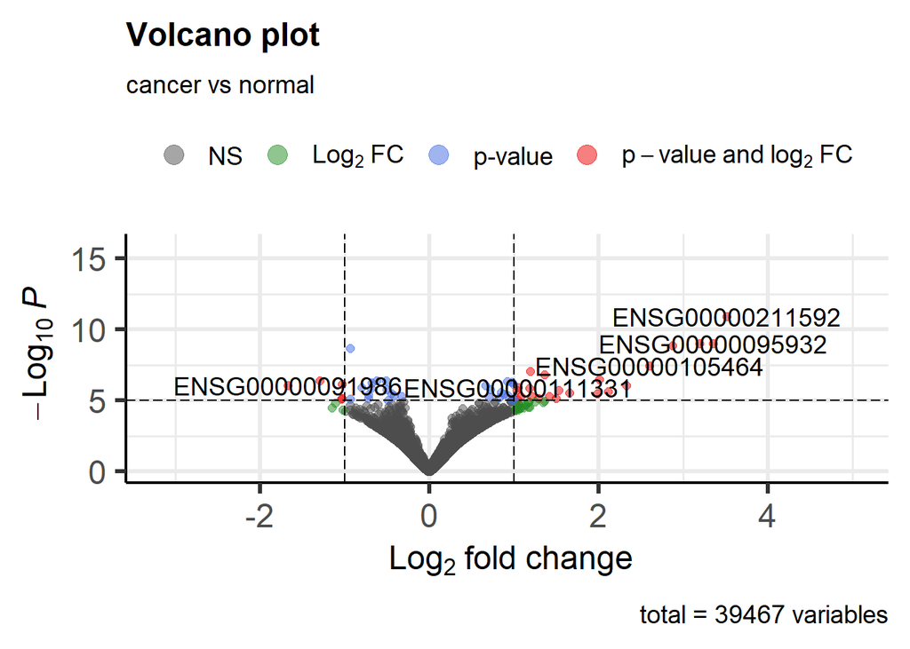

```r
EnhancedVolcano(res_shrinked,
                lab = rownames(res),
                x = "log2FoldChange",
                y = "pvalue",
                subtitle = "cancer vs normal")
```

#### 11)MA plot

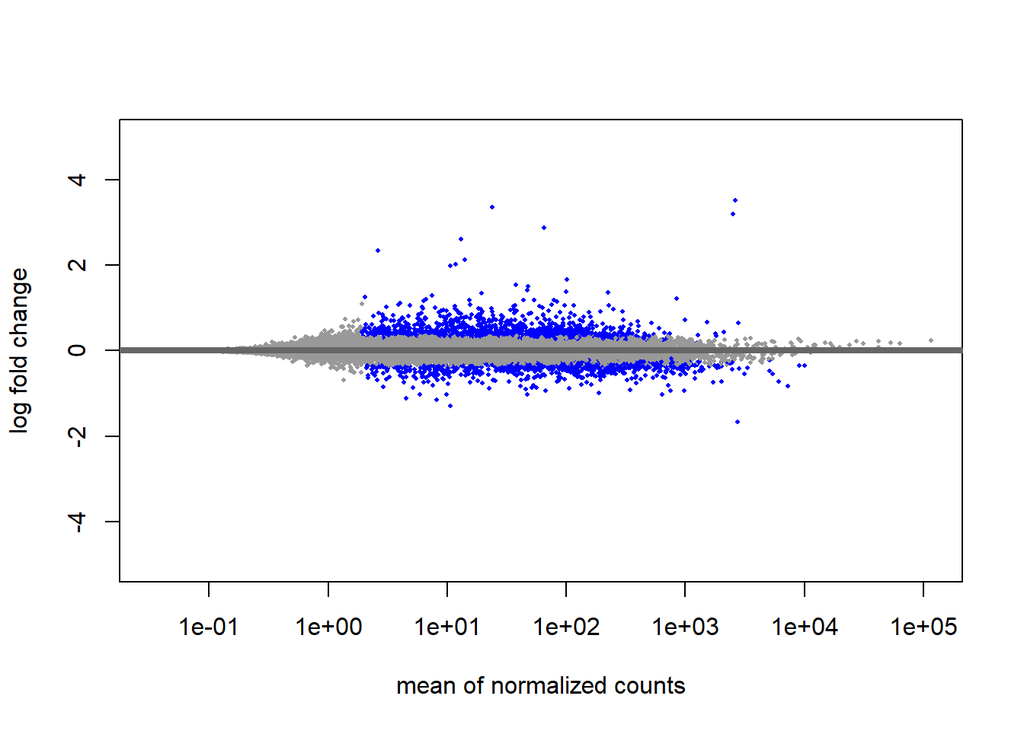

```r
DESeq2::plotMA(res_shrinked, ylim = c(-5, 5)) #MA plot of the results with LFC shrinked for more accuracy
```

#### 12)Heatmap of top 50 DE genes

```r
vsd <- vst(dds, blind = FALSE)
rld <- rlog(dds, blind = FALSE)
```

```
## rlog() may take a few minutes with 30 or more samples,
## vst() is a much faster transformation
```

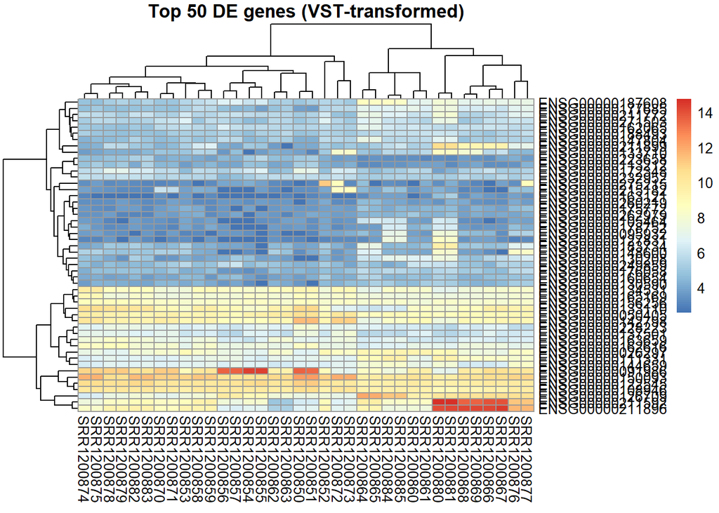

```r
topGenes <- head(order(res$padj), 50)


#using the vsd matrix for the heatmap
mat_vst <- assay(vsd)[topGenes, ]

pheatmap(mat_vst,
         #show_rownames = FALSE,
         main = "Top 50 DE genes (VST-transformed)")
```

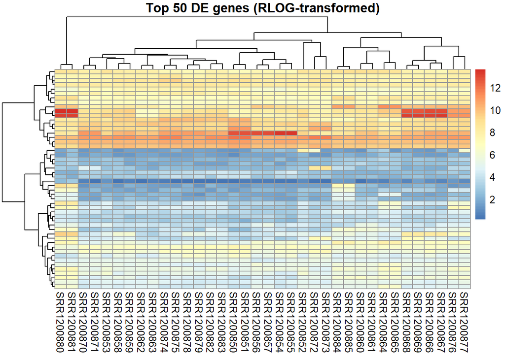

```r
#using the rlog matrix for the heatmap
mat_rlog <- assay(rld)[topGenes, ]

pheatmap(mat_rlog,
         show_rownames = FALSE,
         main = "Top 50 DE genes (RLOG-transformed)")
```

## Step 3: GO & PEA

#### 0)Necessary libraries for this step

```r
library(clusterProfiler)
library(org.Hs.eg.db)
library(AnnotationDbi)
library(ReactomePA)
```

#### 1)Annotating Gene Symbols

```r
res$symbol <- mapIds(
    org.Hs.eg.db,
    keys = rownames(res),
    column = "SYMBOL",
    keytype = "ENSEMBL",
    multiVals = "first"
)
```

#### 2)Getting UP regulated and DOWN regulated genes and defining them with “universe=”

First and foremost, I set up both up and down regulated genes with the appropriate criteria required, and only after that I combine them to run further analysis.

```r
#Up regulated genes
up_genes <- res$symbol[which(res$log2FoldChange > 0 & res$padj < 0.05)]
up_genes <- na.omit(up_genes)

#Down regulated genes
down_genes <- res$symbol[which(res$log2FoldChange < 0 & res$padj < 0.05)]
down_genes <- na.omit(down_genes)

universe_genes <- na.omit(res$symbol)

#Combining genes
comb_genes <- unique(c(up_genes, down_genes))
```

#### 3)Biological process and Molecular factor

Biological process

```r
GO_BP <- enrichGO(gene = comb_genes,
                      universe = universe_genes,
                      OrgDb = org.Hs.eg.db,
                      keyType = "SYMBOL",
                      ont = "BP",
                      pAdjustMethod = "BH",
                      qvalueCutoff = 0.05)
```

Molecular function

```r
GO_MF <- enrichGO(gene = comb_genes,
                      universe = universe_genes,
                      OrgDb = org.Hs.eg.db,
                      keyType = "SYMBOL",
                      ont = "MF",
                      pAdjustMethod = "BH",
                      qvalueCutoff = 0.05)
```

#### 4)Pathway enrichment analysis

First the Map SYMBOL must be changed to ENTREZ ID for the Enrichment analysis to work in comparison to the previous analyses.

```r
PA_entrez <- mapIds(org.Hs.eg.db,
                    keys = comb_genes,
                    column = "ENTREZID",
                    keytype = "SYMBOL",
                    multiVals = "first")
PA_entrez <- na.omit(PA_entrez)
```

Now that the changes are completed the analysis can be ran.

```r
PA <-ReactomePA::enrichPathway(gene = PA_entrez,
                                  organism = "human",
                                  pvalueCutoff = 0.05,
                                  readable = TRUE)
```

#### 5)Making dot-plots of the analyses

Biological process

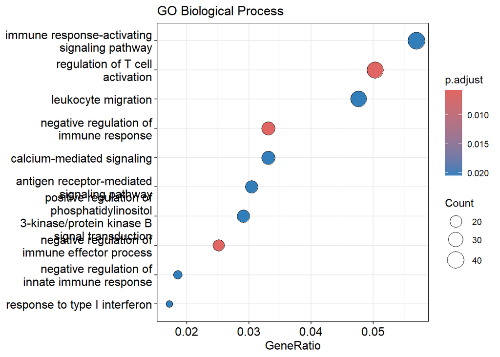

```r
dotplot(GO_BP, title = "GO Biological Process")
```

Molecular function

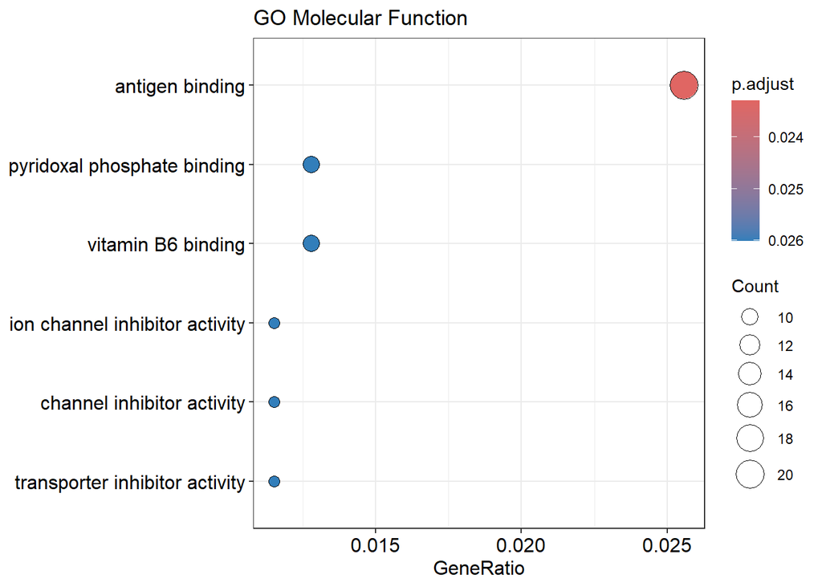

```r
dotplot(GO_MF,title = "GO Molecular Function")
```

Enrichment pathway

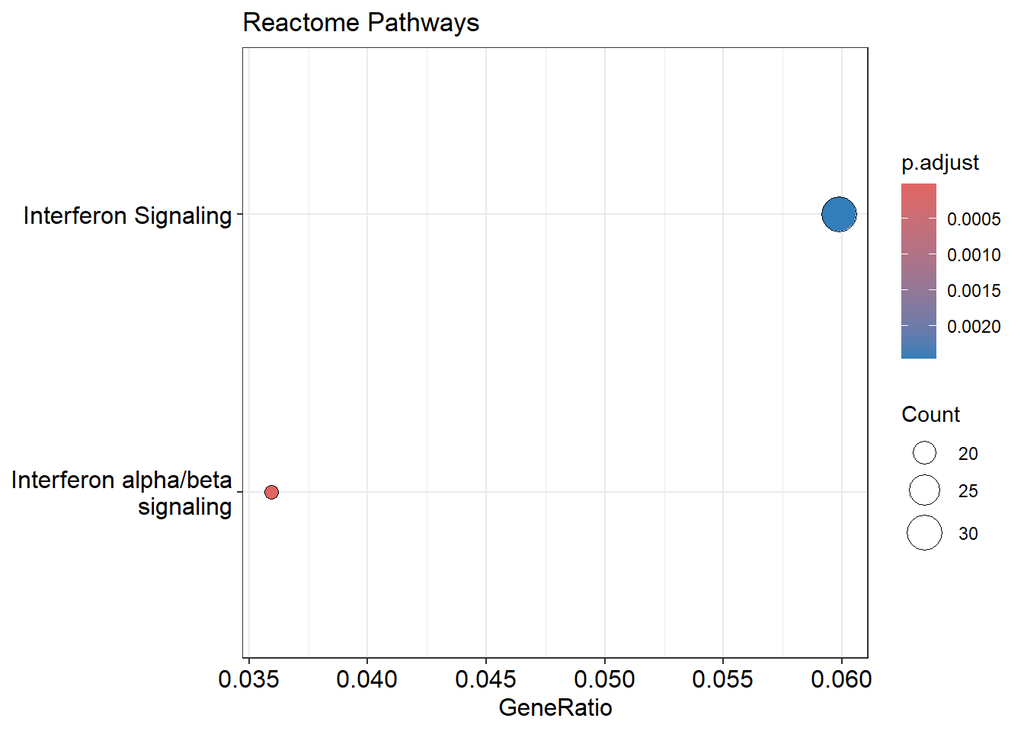

```r
dotplot(PA, title = "Reactome Pathways")
```

# Step 4: GSEA

#### 0)Updating the set of necessary libraries for this step

```r
library(msigdbr)
library(dplyr)
```

```r
library(enrichplot)
```

#### 1)Getting the HALLMARK gene sets

/ Taken from the instruction /

```r
h_gene_sets <- msigdbr(species = "Homo sapiens", category = "H")
msigdbr_t2g <- h_gene_sets %>%
  dplyr::distinct(gs_name, ensembl_gene)  # TERM2GENE format
```

#### 2)Creating the ranked list and running GSEA

```r
rank <- res$stat
names(rank) <- rownames(res)
rank <- sort(rank, decreasing = TRUE)
```

Running GSEA with Hallmark gene sets

```r
gsea <- clusterProfiler::GSEA(geneList = rank,
                              TERM2GENE = msigdbr_t2g,
                              pvalueCutoff = 0.05,
                              verbose = FALSE)
```

#### 3)Plotting Normalized Enrichment Scores

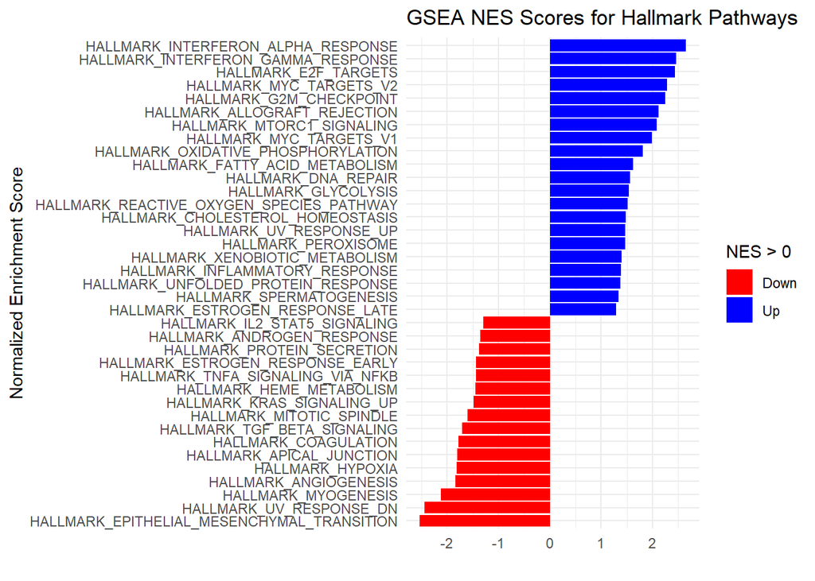

```r
gsea_df <- as.data.frame(gsea)

ggplot(gsea_df, aes(NES, reorder(Description, NES),  fill = NES > 0)) +
  geom_bar(stat = "identity") +
  labs(title = "GSEA NES Scores for Hallmark Pathways", x = "", y = "Normalized Enrichment Score") +
  scale_fill_manual(values = c("red", "blue"), labels = c("Down", "Up")) +
  theme_minimal()
```

#### 4)Enrichment plots of the 5 most enriched Hallmark geneset

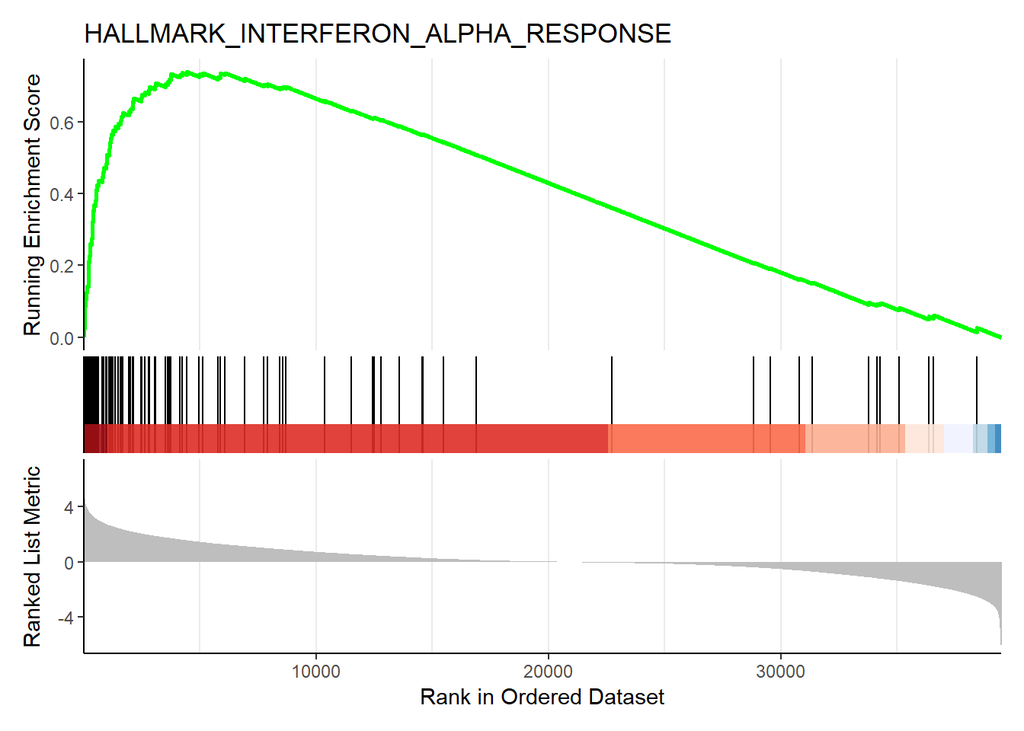

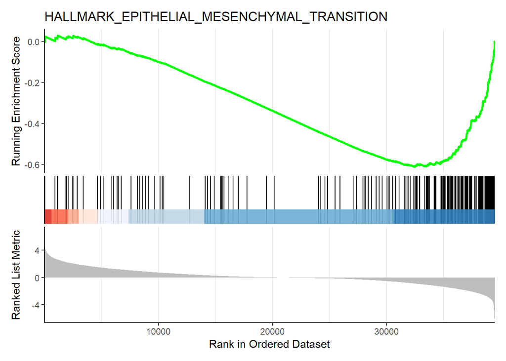

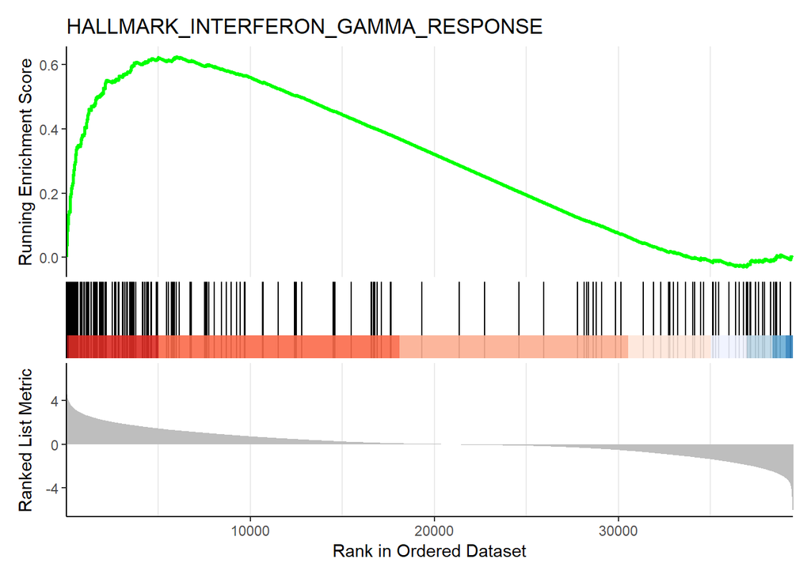

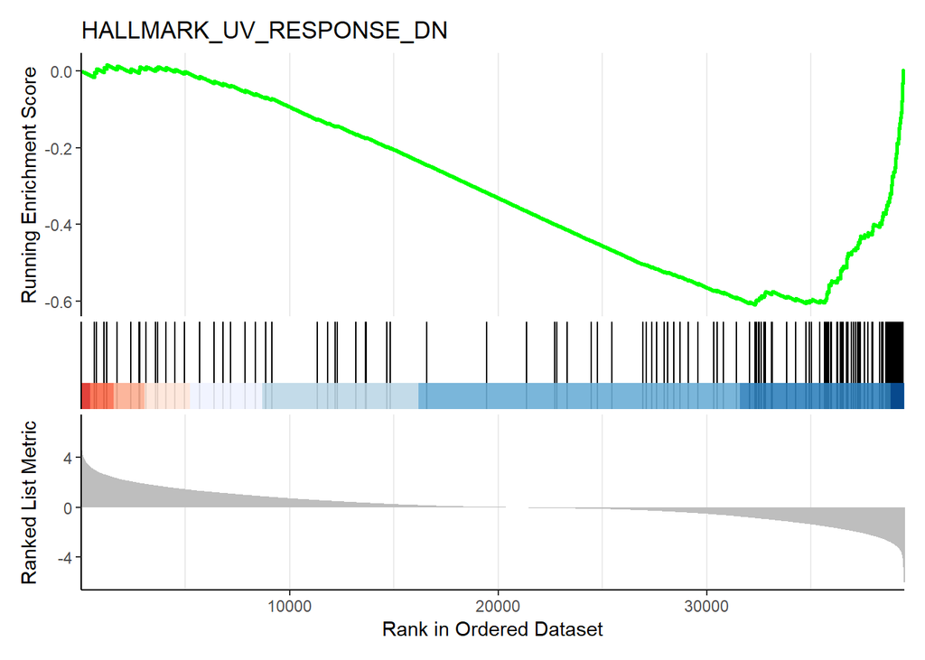

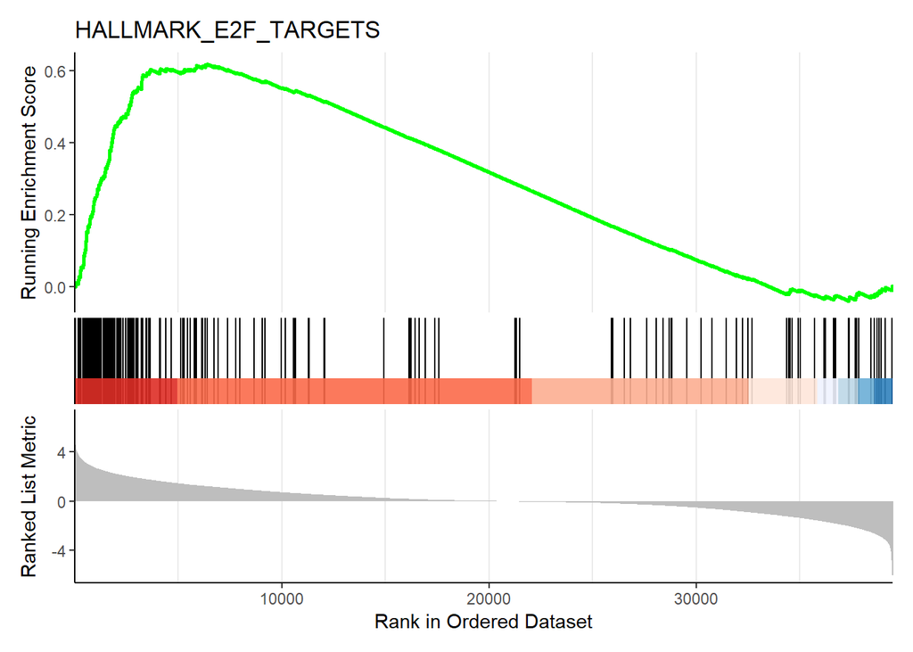

```r
top5 <- head(gsea_df$ID, 5)

for (term in top5) {
  print(gseaplot2(gsea, geneSetID = term, title = term))
}
```

#### 5)Creating Heatmap of core genes

```r
core_genes <- as.vector(stringr::str_split(string = gsea@result$core_enrichment[1], pattern = "/", simplify = TRUE))
```

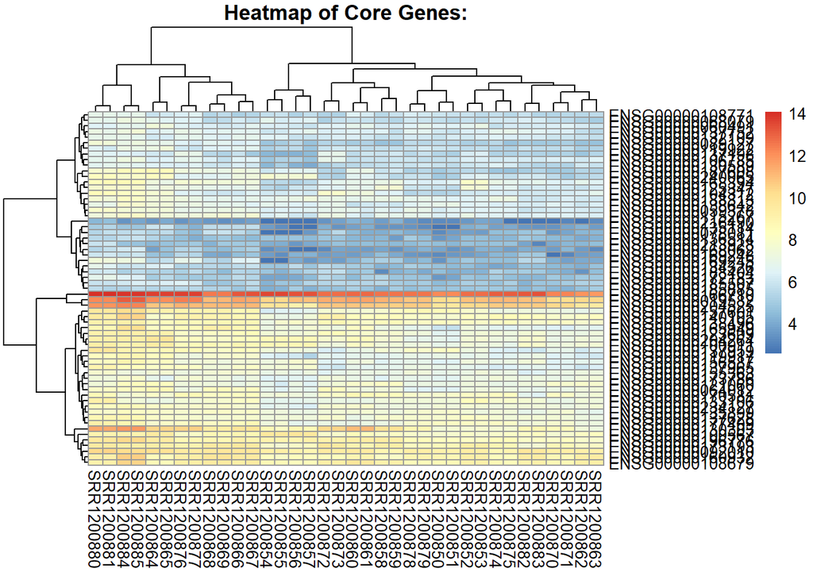

```r
mat_core <- assay(vsd)[core_genes, ]

pheatmap::pheatmap(mat_core,
                   main = paste("Heatmap of Core Genes:"))
```

# Step 5: FastQC

For accessing the according fastq files the following Bioproject code was obtained from the GEO repository: *PRJNA242387*. With this code the appropriate fastq files used for the FastQC were downloaded and used.  
Specifically fastq files with codes: SRR1200851_1 & SRR1200881_2.

# Step 6: MultiQC

HTML form of the report is present in the folder.

#### Interpretation of the results.

The per base sequence quality showed that vast majority of the read had a score of > 30 and so located in the green region, which indicates that the quality of score across all bases was good. Per base sequence content, on the other hand, showed some negative results with one of the sequences being at a warning stage and the other not passing the test. The results of that indicate that an alignment process is required here.  
The GC content, which is an other vital criteria for starting any further downstream differential expression analysis, was at a proper range for the first sample, hence passing the test, but had some skewed regions on the other one and raised a warning.  
Moving on to sequence duplication results, it is again observed that the first sample is at a much better condition and passes the test in comparison to the subsequent one that had raised some warnings indicating moderate duplication. That could be a result of bias which is common in low-input RNA-seq.  
Lastly, adapter content, which is also a vital parameter to better understand the sequences. Here both the samples passed the test indicating that no significant adapters were detected, meaning that trimming of those will not be required at this stage.

# Step 7: Data comparison

Comparison of changes in the obtained results from Expression Atlas results: Are there any differences between log2fold change values.

The genes that I took into account for this comparison are CCDC181 and CDHR1.

CCDC181, with geneID ENSG00000117477, has a log2fold change value of -1.32, which matches the results present on Expression Atlas. CDHR1 on the other hand, with geneID ENSG00000148600, has a log2fold change value of 1.4 to which my results did not match and rather showed a value of 2.78.  
From here I concluded that the expression results were far more accurate and reliable for those genes that were down regulated than up regulated, since the former example is a down regulated one whilst the latter is up regulated.

### Answers to more specific questions

#### 1)How many genes are differentially expressed at the thresholds of padj < 0.05? And padj < 0.1?

```r
#DE genes at padj < 0.05
sum(res$padj < 0.05, na.rm = TRUE)
```

```
## [1] 920
```

```r
#DE genes at padj < 0.1
sum(res$padj < 0.1, na.rm = TRUE)
```

```
## [1] 2019
```

#### 2)How many genes at the thresholds of padj < 0.05 are upregulated ( > 0) or downregulated?

```r
#Total at padj < 0.05
threshold_genes <- res[res$padj < 0.05 & !is.na(res$padj), ]

#upregulated genes (log2FC > 0)
sum(threshold_genes$log2FoldChange > 0)
```

```
## [1] 534
```

```r
#downregulated genes (log2FC < 0)
sum(threshold_genes$log2FoldChange < 0)
```

```
## [1] 386
```

#### 3)Choice one of the GO enrichment results and report how many categories are significant (p.adjust < 0.05).

```r
#Converting GO BP results into a dataframe
GO_BP_df <- as.data.frame(GO_BP)

#Criteria of interest
sum(GO_BP_df$p.adjust < 0.05, na.rm = TRUE)
```

```
## [1] 119
```

#### 4)How many genes are present in the most enriched category of the GO BP enrichment result?

The geneID column contains the **list of genes** associated with that GO term, separated by slashes (/).

```r
head(GO_BP_df, 1)
```

```
##                    ID                                    Description GeneRatio
## GO:0002698 GO:0002698 negative regulation of immune effector process    19/755
##              BgRatio RichFactor FoldEnrichment   zScore      pvalue    p.adjust
## GO:0002698 123/16784  0.1544715       3.433974 5.879942 2.41377e-06 0.005740768
##                 qvalue
## GO:0002698 0.005181076
##                                                                                                                        geneID
## GO:0002698 TBX21/PTPN6/GFER/BST2/SPINK5/CD96/ZBTB7B/LGALS9/ASCL2/LILRB4/HLA-F/HLA-A/HLA-B/IRAK3/TGFB2/PPP3CB/MASP1/FER/ANGPT1
##            Count
## GO:0002698    19
```

After observing them I extract those genes into a variable and count the length of it.

```r
top_enrch_list <- strsplit(GO_BP_df$geneID[1], "/")[[1]]
length(top_enrch_list)
```

```
## [1] 19
```